# Philippine Commission on Women

# 4 Where the money goes

## 4.1 Composition by PREXC program

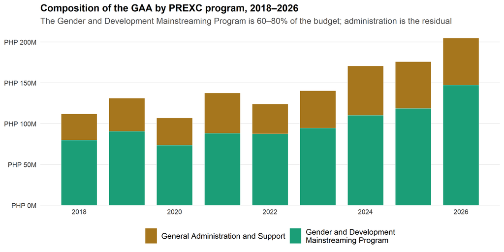

```r
comp <- df_long %>% filter(metric == "GAA", year <= 2026, !is.na(amount), !is.na(category)) %>%
  group_by(year, category) %>% summarise(amount = sum(amount, na.rm = TRUE), .groups = "drop") %>%
  mutate(category = factor(category, levels = names(cat_pal)))
ggplot(comp, aes(year, amount, fill = category)) +
  geom_col(width = 0.75, color = "white", linewidth = 0.2) +
  scale_fill_manual(values = cat_pal, labels = function(x) str_wrap(x, 34)) +
  scale_y_continuous(labels = php_m_axis, breaks = pretty_breaks(6), limits = c(0, NA), expand = expansion(mult = c(0, .05))) +
  scale_x_continuous(breaks = seq(2018, 2026, 2)) +
  labs(title = "Composition of the GAA by PREXC program, 2018–2026",
       subtitle = "The Gender and Development Mainstreaming Program is 60–80% of the budget; administration is the residual",
       x = NULL, y = NULL) +
  theme_pcw() + guides(fill = guide_legend(nrow = 1))
```

The green **GAD Mainstreaming Program** is the budget — 60–80% of the total in every year — with **General Administration and Support** the residual. This is the expected shape for a mandate-delivery agency: most of the money sits in the substantive program, not overhead.

## 4.2 Composition by expense class

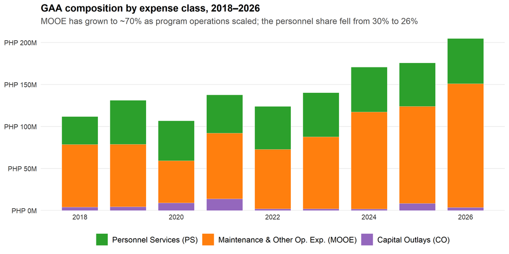

```r
ec_levels <- c("Personnel Services (PS)","Maintenance & Other Op. Exp. (MOOE)","Capital Outlays (CO)")
comp_ec <- df_long_all %>% filter(metric == "GAA", year <= 2026, expense_class %in% c("1PS","2MOOE","6CO")) %>%
  group_by(year, expense_class) %>% summarise(amount = sum(amount, na.rm = TRUE), .groups = "drop") %>%
  mutate(expense_class = factor(expense_class, levels = c("1PS","2MOOE","6CO"), labels = ec_levels))
ggplot(comp_ec, aes(year, amount, fill = expense_class)) +
  geom_col(width = 0.75, color = "white", linewidth = 0.2) +
  scale_fill_manual(values = ec_pal) +
  scale_y_continuous(labels = php_m_axis, breaks = pretty_breaks(6), limits = c(0, NA), expand = expansion(mult = c(0, .05))) +
  scale_x_continuous(breaks = seq(2018, 2026, 2)) +
  labs(title = "GAA composition by expense class, 2018–2026",
       subtitle = "MOOE has grown to ~70% as program operations scaled; the personnel share fell from 30% to 26%",
       x = NULL, y = NULL) +
  theme_pcw() + guides(fill = guide_legend(nrow = 1))
```

```r
comp_ec %>% group_by(year) %>% mutate(share = round(amount/sum(amount)*100)) %>% ungroup() %>%
  select(expense_class, year, share) %>% pivot_wider(names_from = year, values_from = share) %>%
  rename(`Expense class (% of GAA)` = expense_class) %>% kbl_clean(font = 12.5, na = "")
```

| Expense class (% of GAA) | 2018 | 2019 | 2020 | 2021 | 2022 | 2023 | 2024 | 2025 | 2026 |
| --- | --- | --- | --- | --- | --- | --- | --- | --- | --- |
| Personnel Services (PS) | 30 | 40 | 45 | 33 | 41 | 37 | 31 | 29 | 26 |
| Maintenance & Other Op. Exp. (MOOE) | 67 | 57 | 47 | 57 | 57 | 61 | 68 | 66 | 72 |
| Capital Outlays (CO) | 4 | 3 | 8 | 10 | 2 | 1 | 1 | 5 | 2 |

## 4.3 The largest P/A/Ps

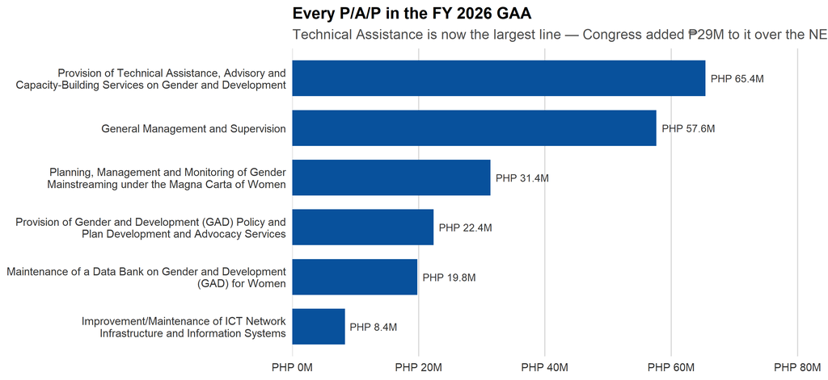

```r
top_paps <- pap_year %>% filter(year == 2026, !is.na(GAA), GAA > 0) %>% arrange(desc(GAA)) %>%
  mutate(pap = factor(pap, levels = rev(pap)))
ggplot(top_paps, aes(pap, GAA)) +
  geom_col(fill = bar_fill, width = 0.72) +
  geom_text(aes(label = php_m(GAA)), hjust = -0.1, size = 3.2, color = "grey20") +
  coord_flip() + scale_x_discrete(labels = function(x) str_wrap(x, 52)) +
  scale_y_continuous(labels = php_m_axis, expand = expansion(mult = c(0, .28)), limits = c(0, NA)) +
  labs(title = "Every P/A/P in the FY 2026 GAA",
       subtitle = "Technical Assistance is now the largest line — Congress added ₱29M to it over the NEP",
       x = NULL, y = NULL) +
  theme_pcw() + theme(panel.grid.major.y = element_blank(), panel.grid.major.x = element_line(color = "grey85"))
```

After the 2026 plus-up, **Technical Assistance and Capacity-Building on GAD (₱65.4M)** is the largest line, ahead of **General Management (₱57.6M)**. The substantive core — Planning & Monitoring under the Magna Carta (₱31.4M), GAD Policy & Plan Development (₱22.4M), and the GAD Data Bank (₱19.8M) — fills out the rest, with ICT infrastructure a small capital line.

### Full P/A/P ranking, FY 2026 (interactive)

```r
pap_year %>% filter(year == 2026, !is.na(GAA)) %>%
  left_join(pap_year %>% filter(year == 2025) %>% transmute(pap, GAA25 = GAA), by = "pap") %>%
  transmute(`P/A/P` = pap, `NEP 2026 (M)` = NEP/1e6, `GAA 2026 (M)` = GAA/1e6,
            `GAA 2025 (M)` = GAA25/1e6, `Net add 2026 (M)` = (GAA - NEP)/1e6) %>%
  arrange(desc(`GAA 2026 (M)`)) %>%
  dt_table(page = 10, money_cols = c("NEP 2026 (M)","GAA 2026 (M)","GAA 2025 (M)","Net add 2026 (M)"))
```

| P/A/P | NEP 2026 (M) | GAA 2026 (M) | GAA 2025 (M) | Net add 2026 (M) |
| --- | --- | --- | --- | --- |
| Provision of Technical Assistance, Advisory and Capacity-Building Services on Gender and Development | 36.387 | 65.387 | 34.464 | 29 |
| General Management and Supervision | 57.646 | 57.646 | 57.179 | 0 |
| Planning, Management and Monitoring of Gender Mainstreaming under the Magna Carta of Women | 31.355 | 31.355 | 25.811 | 0 |
| Provision of Gender and Development (GAD) Policy and Plan Development and Advocacy Services | 22.362 | 22.362 | 21.801 | 0 |
| Maintenance of a Data Bank on Gender and Development (GAD) for Women | 19.788 | 19.788 | 23.934 | 0 |
| Improvement/Maintenance of ICT Network Infrastructure and Information Systems | 8.356 | 8.356 | 9.844 | 0 |

# 5 Where Congress adjusts — and the “Tier 2” pattern

Because every Congressional move at PCW is an *add*, the interesting question is *which* lines get them. The chart sums each P/A/P’s enacted-minus-proposed difference across the whole period.

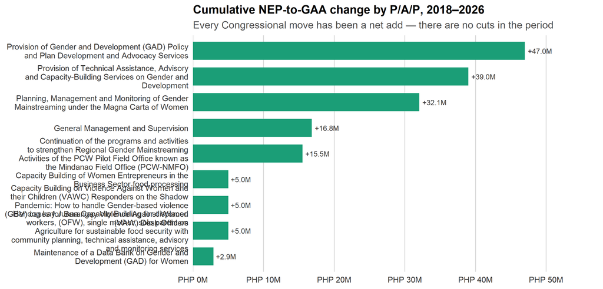

```r
aug <- pap_year %>% group_by(pap) %>%
  summarise(nep = sum(NEP, na.rm = TRUE), gaa = sum(GAA, na.rm = TRUE), .groups = "drop") %>%
  mutate(change = gaa - nep) %>% filter(abs(change) >= 1e6) %>% arrange(desc(change)) %>%
  mutate(pap = factor(pap, levels = rev(pap)))
ggplot(aug, aes(pap, change/1e6)) +
  geom_col(fill = "#1B9E77", width = 0.7) +
  geom_text(aes(label = sprintf("%+.1fM", change/1e6)), hjust = -0.12, size = 3.0, color = "grey20") +
  coord_flip() + scale_x_discrete(labels = function(x) str_wrap(x, 50)) +
  scale_y_continuous(labels = function(v) paste0(peso, v, "M"), expand = expansion(mult = c(0, 0.22))) +
  labs(title = "Cumulative NEP-to-GAA change by P/A/P, 2018–2026",
       subtitle = "Every Congressional move has been a net add — there are no cuts in the period",
       x = NULL, y = NULL) +
  theme_pcw() + theme(panel.grid.major.y = element_blank(), panel.grid.major.x = element_line(color = "grey85"))
```

Two patterns sit side by side. Most of the augmentation flows to the **core operational lines** — steady year-on-year top-ups to Technical Assistance and the other continuing programs. But a meaningful share goes to **one-off “Tier 2” inserts**: the **Continuation of the PCW-NMFO Mindanao Field Office (+₱15.5M)** was a single FY 2023 add for a regional pilot not in the Executive’s proposal, and FY 2022 carried three **₱5M one-offs** — Capacity-Building for VAWC Responders, *Handog kay Juana*, and Capacity-Building for Women Entrepreneurs. Roughly half of PCW’s distinct P/A/Ps over the period are single-year inserts, so part of the GAD agenda is shaped through ad-hoc Congressional initiative rather than the regular Executive plan.

# 6 Absorptive capacity

## 6.1 Aggregate

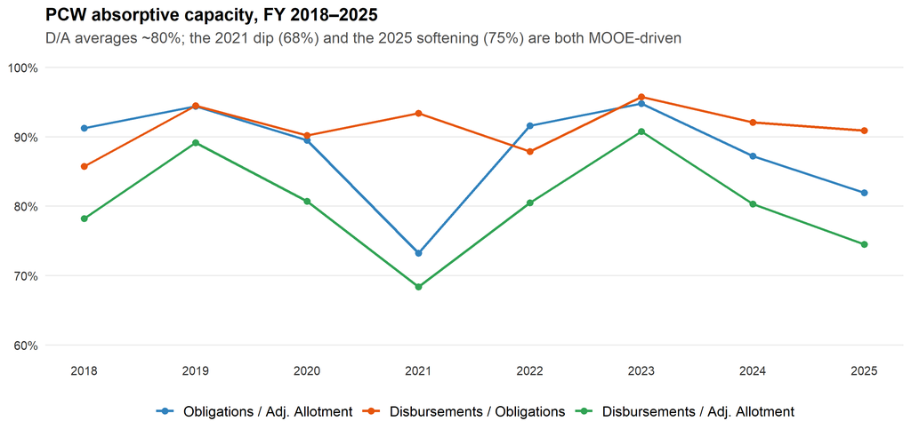

```r
absorp_long <- absorp_total %>% select(year, oblig_allot, disb_oblig, disb_allot) %>%
  pivot_longer(-year, names_to = "ratio", values_to = "value") %>% filter(!is.na(value)) %>%
  mutate(ratio = factor(ratio, levels = c("oblig_allot","disb_oblig","disb_allot"),
    labels = c("Obligations / Adj. Allotment","Disbursements / Obligations","Disbursements / Adj. Allotment")))
ggplot(absorp_long, aes(year, value, color = ratio, group = ratio)) +
  geom_line(linewidth = 0.9) + geom_point(size = 2) +
  scale_color_manual(values = absorp_pal) +
  scale_y_continuous(labels = percent_format(accuracy = 1), limits = c(0.6, 1.0), breaks = seq(0.6, 1, 0.1)) +
  scale_x_continuous(breaks = 2018:2025) +
  labs(title = "PCW absorptive capacity, FY 2018–2025",
       subtitle = "D/A averages ~80%; the 2021 dip (68%) and the 2025 softening (75%) are both MOOE-driven",
       x = NULL, y = NULL) +
  theme_pcw() + guides(color = guide_legend(nrow = 1))
```

## 6.2 By expense class

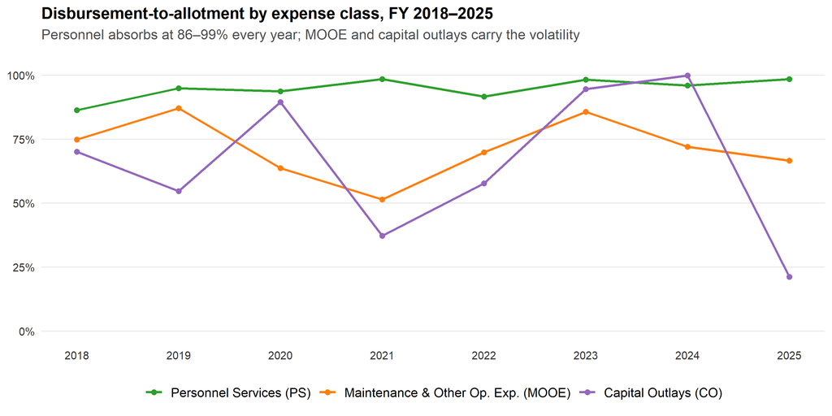

```r
absorp_ec <- df_long_all %>% filter(metric %in% c("AdjAllot","Disbursements"),
    expense_class %in% c("1PS","2MOOE","6CO"), year %in% 2018:2025) %>%
  group_by(year, metric, expense_class) %>% summarise(amount = sum(amount, na.rm = TRUE), .groups = "drop") %>%
  pivot_wider(names_from = metric, values_from = amount) %>%
  mutate(da = ifelse(AdjAllot > 0, Disbursements/AdjAllot, NA_real_),
         expense_class = factor(expense_class, levels = c("1PS","2MOOE","6CO"),
           labels = c("Personnel Services (PS)","Maintenance & Other Op. Exp. (MOOE)","Capital Outlays (CO)")))
ggplot(absorp_ec, aes(year, da, color = expense_class, group = expense_class)) +
  geom_line(linewidth = 0.9) + geom_point(size = 1.8) +
  scale_color_manual(values = ec_pal) +
  scale_y_continuous(labels = percent_format(accuracy = 1), limits = c(0, 1.05), breaks = seq(0, 1, 0.25)) +
  scale_x_continuous(breaks = 2018:2025) +
  labs(title = "Disbursement-to-allotment by expense class, FY 2018–2025",
       subtitle = "Personnel absorbs at 86–99% every year; MOOE and capital outlays carry the volatility",
       x = NULL, y = NULL) +
  theme_pcw() + guides(color = guide_legend(nrow = 1))
```

The split is clean: **personnel disburses at 86–99%** every year — salaries go out reliably — while **MOOE and capital outlays carry all the volatility**. The aggregate weakness in 2025 is a MOOE story: MOOE allotments **doubled from ₱52M (2022) to ₱112M (2025)**, but disbursed at only **67%**. The agency is being handed more operating money than it is currently converting into spending.

## 6.3 Strongest and weakest absorbers, FY 2025

```r
abs25 <- pap_year %>% filter(year == 2025, !is.na(AdjAllot), AdjAllot >= 1e6) %>%
  transmute(`P/A/P` = pap, `Allotment (M)` = AdjAllot/1e6,
            `O/A` = Obligations/AdjAllot, `D/O` = Disbursements/Obligations, `D/A` = Disbursements/AdjAllot) %>%
  arrange(desc(`D/A`))
abs25 %>% dt_table(page = 10, money_cols = "Allotment (M)", pct_cols = c("O/A","D/O","D/A"))
```

| P/A/P | Allotment (M) | O/A | D/O | D/A |
| --- | --- | --- | --- | --- |
| Provision of Gender and Development (GAD) Policy and Plan Development and Advocacy Services | 21.801 | 0.9307590023393423 | 0.9467740204684094 | 0.8812184427319848 |
| Improvement/Maintenance of ICT Network Infrastructure and Information Systems | 9.844 | 0.8702029937017473 | 1 | 0.8702029937017473 |
| Maintenance of a Data Bank on Gender and Development (GAD) for Women | 23.934 | 0.8225229017297568 | 0.9734829908270153 | 0.8007120543995988 |
| General Management and Supervision | 57.179 | 0.8462438928627642 | 0.9210590526801942 | 0.7794405982965774 |
| Development of the Document Management System | 1.123 | 0.7008302938557436 | 1 | 0.7008302938557436 |
| Provision of Technical Assistance, Advisory and Capacity-Building Services on Gender and Development | 34.464 | 0.7653528583449396 | 0.833252683452176 | 0.6377323230037141 |
| Planning, Management and Monitoring of Gender Mainstreaming under the Magna Carta of Women | 25.811 | 0.748440587733912 | 0.8305330293868242 | 0.6216046286467011 |
| Enhancement of Multimedia Bank System | 1.726 | 0.4296817265353419 | 1 | 0.4296817265353419 |

## 6.4 The five long-running operational lines

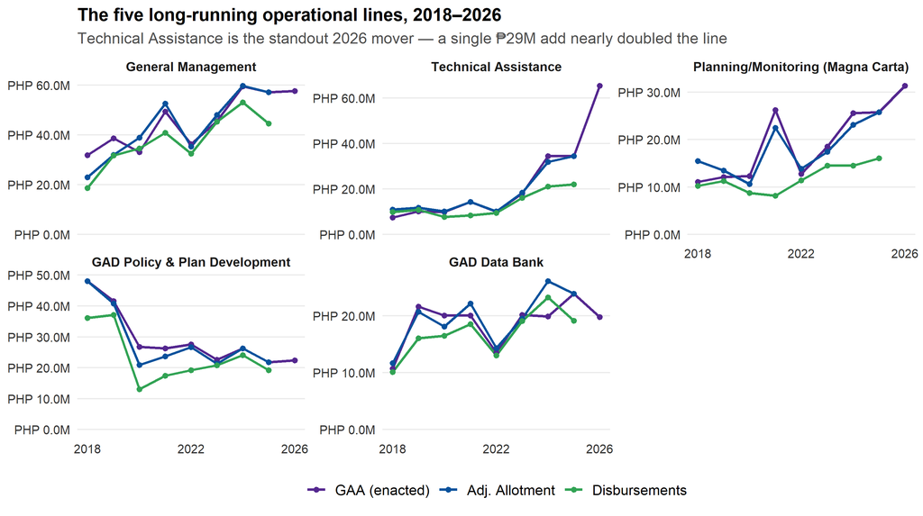

```r
trend_paps <- c(
  "General Management and Supervision",
  "Provision of Technical Assistance, Advisory and Capacity-Building Services on Gender and Development",
  "Planning, Management and Monitoring of Gender Mainstreaming under the Magna Carta of Women",
  "Provision of Gender and Development (GAD) Policy and Plan Development and Advocacy Services",
  "Maintenance of a Data Bank on Gender and Development (GAD) for Women")
trend_lab <- c("General Management","Technical Assistance","Planning/Monitoring (Magna Carta)",
               "GAD Policy & Plan Development","GAD Data Bank")
trend_dat <- pap_year %>% filter(pap %in% trend_paps) %>%
  select(pap, year, GAA, AdjAllot, Disbursements) %>%
  pivot_longer(c(GAA, AdjAllot, Disbursements), names_to = "metric", values_to = "amount") %>%
  filter(!is.na(amount)) %>%
  mutate(metric = factor(metric, levels = c("GAA","AdjAllot","Disbursements"),
           labels = c("GAA (enacted)","Adj. Allotment","Disbursements")),
         pap = factor(pap, levels = trend_paps, labels = trend_lab))
ggplot(trend_dat, aes(year, amount, color = metric, group = metric)) +
  geom_line(linewidth = 0.9) + geom_point(size = 1.5) +
  facet_wrap(~ pap, ncol = 3, scales = "free_y") + expand_limits(y = 0) +
  scale_color_manual(values = c("GAA (enacted)" = "#54278F","Adj. Allotment" = "#08519C","Disbursements" = "#31A354")) +
  scale_y_continuous(labels = php_m, breaks = pretty_breaks(4)) +
  scale_x_continuous(breaks = c(2018, 2022, 2026)) +
  labs(title = "The five long-running operational lines, 2018–2026",
       subtitle = "Technical Assistance is the standout 2026 mover — a single ₱29M add nearly doubled the line",
       x = NULL, y = NULL) +
  theme_pcw() + guides(color = guide_legend(nrow = 1))
```

The five continuing lines are the backbone of the agency. Most grow gently; **Technical Assistance** is the exception, jumping in 2026 on the Congressional add — a line whose enacted budget now runs well ahead of the disbursements it managed in prior years, which is exactly why its absorption bears watching.

# 7 Questions for discussion

1. **Can the agency absorb the doubled Technical Assistance line?** Congress lifted it to ₱65M for 2026, but its FY 2025 disbursement-to-allotment was only 64%. What capacity-building activities does the add target, and is the delivery machinery in place?
2. **The MOOE absorption gap.** MOOE allotments more than doubled to ₱112M by 2025 but disbursed at 67%. Is this a procurement bottleneck, a staffing constraint, or a program-design issue?
3. **The “Tier 2” insert pattern.** Roughly half of PCW’s P/A/Ps over the period are one-off Congressional inserts. Are these strengthening the GAD agenda, or fragmenting it into ad-hoc initiatives that lapse with each budget cycle?
4. **The departmental reclassification.** PCW moved from the Other Executive Offices to the DILG in 2019. Has placing a gender-policy agency inside a public-order department strengthened mainstreaming across LGUs, or created tension with its mandate?
5. **The ₱205M ceiling.** Set against the breadth of the Magna Carta of Women, is ₱205M an adequate operating budget for the lead national agency on gender mainstreaming — particularly when its parent department operates on a budget orders of magnitude larger?

Underlying data: DBM-published budget and execution data for the Philippine Commission on Women (Current New Appropriations only), FY 2018–2026; execution measures (Adjusted Allotments, Obligations, Disbursements) cover FY 2018–2025. PCW was reclassified from the Other Executive Offices to the DILG starting FY 2019 and is presented here as one continuous series. Prepared as the long-form companion to the PCW budget briefing.